# Report

## Task One

**Hypothesis**

*Whether or not participants showed a reliable decrease in their stress at follow-up (reliable_change) will be predicted by which intervention (trial_arm) they received, but this effect will be moderated by their levels of engagement with mindfullness having the greatest effect when engagement is high*

**The design**

As there are two independant variables (trail arm and engagement) that predicts a categorical dependant variable (reliable change), logistic regression will be used to test the hypothesis.

**Exploring the data**

*Frequency table*

Data analysis will begin by exploring the data of the independant variable (reliable change) and the dependant variable (trial arm) through the use of a frequency table. I will use the pivot_wider() function in order to spread “reliable change” and “no reliable change” across collumns, in order to make the frequency table more coherant. The table will group the data by all combinations of reliable change and trial group, which will intially indicate which trial group has a higher frequency for reliable change. I will be looking to see if the frequency for each trial group is different in the reliable change groups. This is useful information as it will allow an intial understanding of how the trial arm predicts for reliable change. Lastly, ill be looking to see if there are any missing values within the data, if so, when creating the model i will use the “na.action” function to omit the misssing values in order to avoid issues relating to incomplete information.

**Coding the conditions**

In order to accurately interprate the data, the outcome variable will be coded as 1) “No reliable change” 2) “Reliable change” and the independent variable trial arm will be coded as 1) Psychosocial 2) Mindfullness. This makes the most sense as testing the odds for reliable change is more sensible then testing the odds for no reliable change. So therefore the baseline condition is the psychosocial trial. The independant variable engagement is ordinal, therefore this variable does not need to be coded.

**Fitting the model (with only trial arm)**

*Model parameters*

The dependent variable (reliable change) and the independent variable (trial arm) will then be fit to a model using the glm() function to gain the model parameters. The logg odds produced will then be converted into exponentiated values, using “exponentiate = TRUE” in efforts to make data more coherent to the reader. I will be looking at the intercept (baseline condition) model parameters to see how large the effect of the the psychosocial group is, in order to understand the direction of the relationship. Furthermore, i will also report the odds ratio (b1), i will be looking to see if odds ratio is above or below the value of 1. A value above 1 would indicate that as the predictor variable increases so does the odds of the categorical variable, and the inverse applies to values less than 1. This will allow more information on which trial group has the larger odds for reliable change. Furthermore, i will also report both the p-values and the confidence intervals of the model paramerters. The p-values will provide more information on whether the effect is significant. The confidence intervals will allow more insight into the variation of probability.

*Assessing the overall fit*

The residual deviance for the intercept and the model will then be compared, if the residual deviance for the intercept is larger than the value for the model this will indicate that the addition of the predictor trial arm improves the fit of the model. A Chi-squared value <0.01 will indicate how much better the model predicts the outcome variable (reliable change). If the residual difference for the intercept (b0) is not significantly larger that may imply that the improvement of the fit is not significant.

**Fitting the model (with trial arm and engagement)**

The model will then be fit in one step instead of using a heirachal variable entry, this is because the there is no need to build up the model in a theory driven way nor is there a need to quantify the significance of several categories as the current hypothesis is only testing two predictors and one outcome variable.

*Reporting the new model parameters*

The model will now be extended to include engagement in order to test whether engagement acts as a moderator for the effect of trial arm on reliable change. The exponentiated model parameters for the b0, b1, b2, and the interaction will be reported and interpreted in order to understand the relationship between the independant variable and dependant variable. A parameter estimate larger than 1 for the effect of trial arm and engagement would imply that as the independant variable increases so do the odds from reliable change. A parameter estimate smaller than 1 would imply as the independant variable increases the odds of the dependant variable decreases. In order to confirm the hypothesis, it is important that the odds ratios are above 1. The p-value of the full model parameters will be reported, in order to establish whether the effect is significant. Furthermore, the confidence will again be interprated to gage the variance.

*Plotting the interaction*

*Viewing the exponentiated parameter estimates for each trial group*

In order to further break down the interaction and gain a clearer understanding of the data, i will create separate models for mindfullnes and psychosocial trial groups: using the glm() argument “subset”. I will be looking to see if the model parameters are largely different in each group as well as if the values are above or below 1 and finally whether these values are significant. For example, if one trial group has a positive (b1) value and the other trial group has a negative this may indicate engagement is not effective in both trials.

**Test assumptions**

I will then test for multicollinearity as this is one of the main assumptions of a logistic regression. If colliniearity is identified, this would suggest that the two predictor variables (engagement and trial group) are highly correlated/associated. Therfore, if collinearity is identified, one predictor variable will eithe have to be ommitted or more data would need to be collected the lessen the problem of collinearity.

**Robust model** Finally, i will fit a robust logistic regression. This is useful as the current analysis plan does not test for outliers or influential cases so a robust model will allow insight into, if there are any outliers/influential cases, whether it has effected the original model. This will be achieved by fitting a robust model and viewing its exponentiated model parameters. If the model parameters are similar to the original values this would imply that any outliers or influential cases have not had a great effect on the reported values, however if the values are different this would imply outliers/influential cases have been at play and effected the model and so the data should be cautiously interpreted.

## Task 2

**Description of the GLM (Logistic regression)**

A logistic regression is a statistical model that uses a logistic function to predict the probability of a binary outcome under one or several independant variables. A binary outcome variable has two levels (categorical), either where an event happens or does not happen (ie, reliable change or no reliable change). The independent variables involved are those factors/variables which may influence the outcome (engagement and trial arm); independent variables can be either continuous, ordinal or nominal. The general formula for a logistic regression is stated below.

$$P\hat{(Y)} = \frac{1}{1 + e^{-(\hat{b_0}+\hat{b_1}X_i+e_i)}}$$
• P(Y) is the predicted probability of Y occurring

• b0 stands for the intercept (which is always constant)

• b1 stands for a weight or a slope, otherwise reffered to as the coefficient. This determines how much weight one variable contributes to the model.

• e stand for the error in the model. e is the base of natural logarithms

**The hypothesis**

*Whether or not participants showed a reliable decrease in their stress at follow-up (reliable_change) will be predicted by which intervention (trial_arm) they received, but this effect will be moderated by their levels of engagement with mindfullness having the greatest effect when engagement is high*

Therefore, as the report tests a categorical outcome (reliable change) predicted by a nominal predictor variable (trial arm) and an ordinal predictor variable (engagement), a logistic regression model is best suited to test the hypothesis. This design allows researchers to assess whether reliable change is predicted by the intervention and engagement with the use of probalility. This will result in a conclusion that tests the proability of reliable change in each trial moderated by the participants engagement.

**Equation for the current logistic regression**

$$P\hat{(\text{reliable change})} = \frac{1}{1 + e^{-(\hat{b_0}+\hat{b_1}\text{trial}_i+\hat{b_2}\text{engagement}_ie_i)}}$$

**The assumptions of logistic regression**

There are also a number of assumptions that a logistic regression must meet: linearity of the logit, spherical residuals, multicollinearity.

*Linearity of the logit*

In regards to logistic regression, linearity relates to the assumption that there is a linear relationship between the continuous predictor/s and the logit of the outcome variable.

*Independence of errors*

This relates to the assumption that cases of data should not be related. To elaborate, you cannot use the same participant for multiple sets of data.

*Multicollinearity*

Multicollinearity is a statistical term in which two or more predictor variables in a multiple logistic regression model are highly correlated or associated. This can be a problem as it can cause unstable estimates and inaccurate variances which affects confidence intervals. This can be tested by producing VIF values, if the values are over 10 this would suggest that the predictor variable are highly correlated. The main solution if collinearity is identified is to omit one of the variables, however it is hard to know which variable to omit. Therefore, collecting more data is the best way to reduce the problem of collinearity.

**Potential issues**

There are also some potential issues that researchers should be aware of:

*Incomplete information*

Incomplete information relates to the issue that when dealing with a categorical outcome the data is more likely to suffer from sparseness. In some cases, there may be a lack of cases for each scenario (for example, reliable change in relation to a level of engagement and trial arm). This results in gaps in our knowledge which in turn can inflate the standard errors within the model. This problem can be avoided by checking that all combinations of the variables have been collected before analysis by using a crosstabulation table.

*Complete seperation*

Finally, complete seperation refers to when the outcome variable can be perfectly predicted. For example, a data set where the values for the outcome variable are vastly different across the independant variable. This results in an infinite number of models (predicted values) that can fit the data set, which is problematic as the model can have infinite conclusions.

## Task 3

### Preparing data for analysis

**Loaded packages**

```r
library(tidyverse)
library(car)
```

**Loaded data and filtered tibble**

```r
mindful_tib <- here::here("data/tap_mindfulness.csv")%>%
  readr::read_csv()%>%
dplyr::mutate(
    reliable_change = forcats::as_factor(reliable_change),
    trial_arm = forcats::as_factor(trial_arm)
    )

mindful_tib <- mindful_tib %>%
  dplyr::filter(time == "Follow-up")
```

**Checking the levels**

```r
levels(mindful_tib$trial_arm)
```

```
## [1] "Psychosocial information" "Mindfullness"
```

```r
levels(mindful_tib$reliable_change)
```

```
## [1] "No reliable decrease" "Reliable decrease"
```

### Exploring the data

**Interprating the frequency table**

```r
mindful_xtab <- mindful_tib%>%
dplyr::group_by(trial_arm, reliable_change)%>%
dplyr::summarize(n=n())

mindful_xtab <- mindful_xtab %>%
  tidyr::pivot_wider(
    id_cols = "trial_arm",
    names_from = "reliable_change",
    values_from= "n"
  )

mindful_xtab%>%
  knitr::kable(digits = 2, caption = "Table 1: Frequency Table")
```

Table 1: Frequency Table

| trial_arm | No reliable decrease | Reliable decrease | NA |
| --- | --- | --- | --- |
| Psychosocial information | 206 | 66 | 1 |
| Mindfullness | 169 | 92 | NA |

Note, the frequency for “reliable decrease” in the psychosocial trial arm (n=66) is lower than that of the minfullness group (n=92). Furthermore, the frequency for “no reliable decrease” is higher in the psychsocial group (206) compared to the mundfullness group (169). Lastly, there is one NA value in the psychosocial group, which later i will omit from the data base.

### Fitting the model (single predictor)

**Interprating the model parameters**

```r
mindful_glm <- glm(reliable_change ~trial_arm, data=mindful_tib, family= binomial(), na.action = na.exclude)

broom::tidy(mindful_glm, conf.int = TRUE, exponentiate = TRUE)%>%
  knitr::kable(digits = 2, caption = "Table 2: Exponentiated model parameters")
```

Table 2: Exponentiated model parameters

| term | estimate | std.error | statistic | p.value | conf.low | conf.high |
| --- | --- | --- | --- | --- | --- | --- |
| (Intercept) | 0.32 | 0.14 | -8.05 | 0.00 | 0.24 | 0.42 |
| trial_armMindfullness | 1.70 | 0.19 | 2.76 | 0.01 | 1.17 | 2.48 |

Assuming the current sample is of the 95% where the confidence interval contains the true value, then the population value of the odds ratio for trial arm lies between 1.17 and 2.48. As both values are larger than 1 this indicates that the direction of e relationship observed reflects the population.

**Assessing overall fit**

```r
mindful_int <- glm(reliable_change ~ 1, data = mindful_tib, family = binomial(), na.action = na.exclude)
mindful_trial <- glm(reliable_change ~ trial_arm, data= mindful_tib, binomial(), na.action = na.exclude)
anova(mindful_int, mindful_trial, test = "Chisq")%>%
  knitr::kable(digits = 2, caption = "Table 3: Fit statistics")
```

Table 3: Fit statistics

| Resid. Df | Resid. Dev | Df | Deviance | Pr(>Chi) |
| --- | --- | --- | --- | --- |
| 532 | 647.93 | NA | NA | NA |
| 531 | 640.20 | 1 | 7.73 | 0.01 |

Note, that the residual deviance for the intercept (647.93) is larger than the model which includes trial_arm. A reduction of 7.73 indicates the deviance is smaller and therefore the fit has improved. The significant chi-square value (0.01) tells that by including trial_arm as a predictor the fit of the model significantly improves.

### Fitting the model (Multiple predictors)

**Extending the model**

```r
mindful_full_glm <- glm(reliable_change ~ trial_arm*engagement, data= mindful_tib, family=binomial(), na.action = na.exclude)

broom::tidy(mindful_full_glm, conf.int = TRUE, exponentiate = TRUE)%>%
  knitr::kable(digits = 2, caption = "Table 4: Full expentiated model parameters")
```

Table 4: Full expentiated model parameters

| term | estimate | std.error | statistic | p.value | conf.low | conf.high |
| --- | --- | --- | --- | --- | --- | --- |
| (Intercept) | 0.18 | 0.21 | -7.97 | 0.00 | 0.12 | 0.28 |
| trial_armMindfullness | 2.26 | 0.29 | 2.86 | 0.00 | 1.30 | 3.99 |
| engagement | 1.41 | 0.09 | 3.97 | 0.00 | 1.19 | 1.68 |
| trial_armMindfullness:engagement | 0.80 | 0.11 | -2.10 | 0.04 | 0.65 | 0.98 |

The effects of trial_arm (2.26) and engagemnent (1.41) are both above 1 and are significant (p < 0.01), suggesting that the type trial had a significantly large effect on reliable change after the addition of the effect of mindfullness.

Engagement also is seen to have a significantly large effect (1.41), where as the predictor variable increases the odds of reliable change increase by but not at the same level as trial arm which has a much larger effect size (2.26).

Assuming the current sample is of the 95% where the confidence interval contains the true value, then the population value of the odds ratio for all model estimates do not cross 1. This gives us confidence that the direction of the relationship observed is true in the population.

Note, the odds ratio for for the engagement in the psychosocial group relative to the mindfullness group is 0.80 with an associated p value of 0.04, which indicates that engagement has a larger effect on the baseline condition (psychosocial) than the mindfullness group. However as this value is close to 1, this may indicate the effect is not largely significant.

**Plotting the interaction**

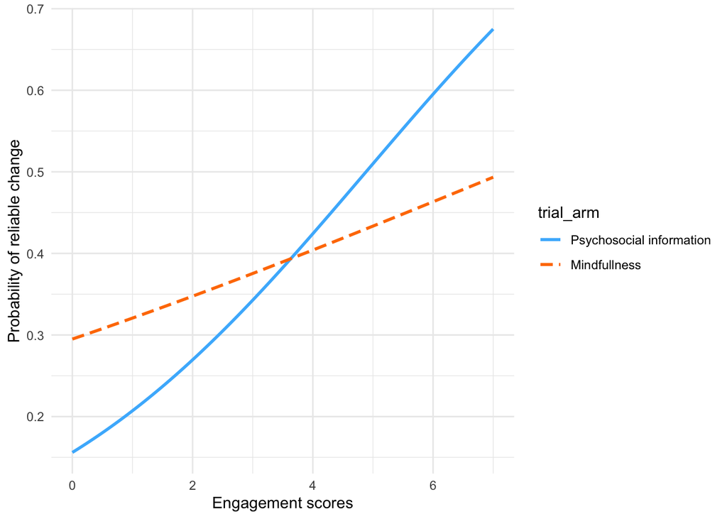

```r
interactions::interact_plot(mindful_full_glm, pred = engagement, modx = trial_arm) +
labs(x="Engagement scores", y="Probability of reliable change", fill ="Trial group")+
theme_minimal()
```

The plot shows that the psychosocial and the mindfullness trial arms both change as the engagement increases, where as the engagement increases so does the probability of reliable change.

The plot indicates that the psychosocial trial group has the greatest effect when engagement is high compared to the mindfullness trial group.

In support of the hypothesis the plot shows the odds of reliable change are highest when engagement is high.

**Breaking down the interaction**

```r
psychos_glm <- glm(reliable_change ~ engagement, data = mindful_tib, subset = trial_arm == "Psychosocial information", family = binomial())

broom::tidy(psychos_glm, conf.int = TRUE, exponentiate = TRUE)%>%
  knitr::kable(digits = 2, caption = "Table 5: Filtered model parameters for psychosocial trial")
```

Table 5: Filtered model parameters for psychosocial trial

| term | estimate | std.error | statistic | p.value | conf.low | conf.high |
| --- | --- | --- | --- | --- | --- | --- |
| (Intercept) | 0.18 | 0.21 | -7.97 | 0 | 0.12 | 0.28 |
| engagement | 1.41 | 0.09 | 3.97 | 0 | 1.19 | 1.68 |

The odds ratio is 1.41 for the psychosocial group, thereby as the engagement increased by 1 unit the odds of reliable changed by 1.41.

The odds ratio is larger than 1 and the p<0.001, which suggests that the engagement has a positive effect on reliable change; where as the engagement increases the odds of reliable change increases. This is shown previously by the interaction plot: as engagement increases the probability of reliable change further increases.

The confidence intervals are 1.19 and 1.68, therefor assuming the sample is of the 95% where the confidence interval contain the true value then the odds ratio does not cross 1, which gives confidence that the direction of the relationship observed (positive) is true.

```r
mindfullness_glm <- glm(reliable_change ~ engagement, data = mindful_tib, subset = trial_arm == "Mindfullness", family = binomial())

broom::tidy(mindfullness_glm, conf.int = TRUE, exponentiate = TRUE)%>%
  knitr::kable(digits = 2, caption = "Table 6: Filtered model parameters for mindfullness trial")
```

Table 6: Filtered model parameters for mindfullness trial

| term | estimate | std.error | statistic | p.value | conf.low | conf.high |
| --- | --- | --- | --- | --- | --- | --- |
| (Intercept) | 0.42 | 0.19 | -4.55 | 0.00 | 0.29 | 0.61 |
| engagement | 1.13 | 0.06 | 1.93 | 0.05 | 1.00 | 1.28 |

The odds ratio is 1.13 for the mindfullness group, thereby as the engagement increased by 1 unit the odds of reliable changed by 1.13.

The odds ratio is close to 1 and the p=0.05, which suggests that engagement has a minimal effect on reliable change; where as engagement increases the odds of reliable change increases by a small amount.

**The overall fit of the full model**

```r
anova(mindful_glm, mindful_full_glm, test = "Chisq")%>%
  knitr::kable(digits = 2, caption = "Table 7: Fit statistics of full model")
```

Table 7: Fit statistics of full model

| Resid. Df | Resid. Dev | Df | Deviance | Pr(>Chi) |
| --- | --- | --- | --- | --- |
| 531 | 640.20 | NA | NA | NA |
| 529 | 620.35 | 2 | 19.85 | 0 |

### Testing assumptions

**Testing for multicollinearity**

```r
vif(mindful_full_glm)
```

```
##            trial_arm           engagement trial_arm:engagement
##             2.123109             2.983203             4.439321
```

```r
1/vif(mindful_full_glm)
```

```
##            trial_arm           engagement trial_arm:engagement
##            0.4710075            0.3352102            0.2252597
```

The VIF values are under 10 therefore do not suggest any major problems regarding the collinearity of the model.

### Robust logistic regression

```r
mindful_rob <- robustbase::glmrob(reliable_change ~ trial_arm*engagement, data = mindful_tib, family = binomial(), na.action =na.exclude)
  broom::tidy(mindful_rob, conf.int = TRUE) %>%
  dplyr::mutate(
    OR = exp(estimate)
  )%>%
  knitr::kable(digits = 2, caption = "Table 8: Robust model parameters")
```

Table 8: Robust model parameters

| term | estimate | std.error | statistic | p.value | conf.low | conf.high | OR |
| --- | --- | --- | --- | --- | --- | --- | --- |
| (Intercept) | -1.68 | 0.22 | -7.78 | 0.00 | -2.10 | -1.26 | 0.19 |
| trial_armMindfullness | 0.81 | 0.29 | 2.82 | 0.00 | 0.25 | 1.38 | 2.26 |
| engagement | 0.34 | 0.09 | 3.89 | 0.00 | 0.17 | 0.52 | 1.41 |
| trial_armMindfullness:engagement | -0.22 | 0.11 | -2.07 | 0.04 | -0.44 | -0.01 | 0.80 |

Note, the exponentiated model parameters labelled as “OR” in the table are the same values reported in the non-robust model. Therefore, the robust model gives confidence that the values of the original model are trustworthy.

**Conclusion**

*Whether or not participants showed a reliable decrease in their stress at follow-up (reliable_change) will be predicted by which intervention (trial_arm) they received*

*but this effect will be moderated by their levels of engagement*

The second part of the hypothesis test whether the trial arm is moderated by the effect of engagement. After extending the model to include engagement, the model parameters for engagement suggest a significantly positive effect for after the addition of engagement as a predictor. Furthermore, the odds ratio for the interaction effect of trial arm and engagement is a positive value below 1, which indicates that engagement has a larger effect on the baseline condition (psychosocial) than the mindfullness condition. This is further supported by the interaction plot, which clearly shows that as engagement rises the probalility of reliable change also increases.

## Task 4

**Reflective Log**

The first challenge I faced at the beggining of this report was understanding which way round to code the levels of the categorical outcome. I was unsure of whether to put “reliable change” or “non reliable change” first. For a while this began to frustrate me as I couldn’t start the analysis untill i understood the correct way to arrange the levels in order to address the hypothesis. Looking through tutorial 20 I stumbled on some information i found useful, the example put the “no delivery” as the baseline and “delivery” as the 2nd condition as the hypothesis was testing the probability of delivery. It finally clicked. As the hypothesis was to test *Whether or not participants showed a reliable decrease* it made more sense to have “reliable change” as the 2nd condition as an increase in the odds would suggest an increase in the odds of reliable change, therefore making the data easier to interprate.

Another challenge was that i was unsure of how to test the assumptions of a logistic regression model. Looking through discovr 20 noticed this was not part of the taught content, however i knew that it was covered briefly in the lecture. In order to fully understand which assumptions to test i scoured the slides and re-watched the lecture in order to gain a better understanding. The lecture mentioned multicollinearity, linearity of the logit and independence of errors as the main assumptions. There were also specific things mentioned that could go wrong with a logistic regression such as incomplete information and complete seperation, however i needed more information in order to fully understand. So i went to Professor Andy Field’s book and read through his chapter on logistic regression, this was extremely helpfull and gave me a deeper understanding of what each assumption meant, however I was still unable to understand how to test the above assumptions. This made me unsure of how to tackle the hypothesis as i know that testing the assumptions of a model is essential to fitting the appropriate model. So, i went the extra mile and goggled how to perform a multicollinearity test of logistic regression. A number of results came up and i spent a decent amount of time trying to download the appropriate packages in order to conduct the VIF test. In the end, i figured out i needed to download the “afex” package and the “car” package. Once i did this i performed a VIF test and was able to interprate the data. This made me feel proud, as my determination drived me to learn extra content that i believe in the end made my report stronger than it previously was. This has taught me that even though some areas may not be covered in the module using my intiative is beneficial in order to develop my skills further as a statistician, i will continue this mindset across all areas of my masters degree now and not just be dependant on the taught material.